# Problem3B

Martine Middelthon and Helene Behrens

2 april 2020

## Problem B

We consider data of bilirubin concentration in blood of three different patients.

```r
bilirubin <- read.table("https://www.math.ntnu.no/emner/TMA4300/2020v/Exercise/ex3-additionalFiles/bilirubin.txt", header=T)
```

We plot this data for the three different individuals to compare their bilirubin concentrations. The resulting box-plots are seen below.

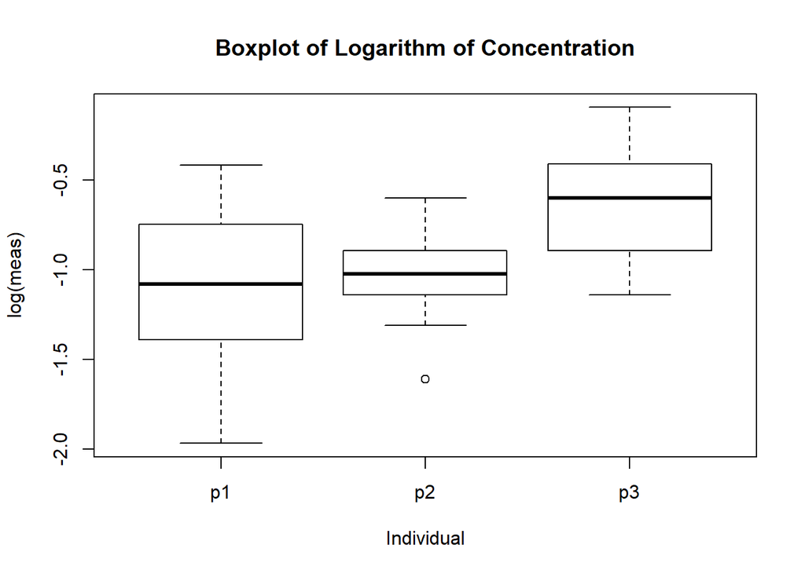

```r
#  boxplot of logarithms of concentration for each indivicual:
boxplot(log(meas)~pers, data=bilirubin,
        main="Boxplot of Logarithm of Concentration", xlab="Individual", ylab="log(meas)")
```

From this plot, we observe a clear tendency that the bilirubin levels are higher for person 3 (p3) than for person 1 and person 2. We want to invesigate wether this difference is significant. We use the $\texttt{lm}$ function to fit the regression model
$$\log(Y_{ij}) = \beta_i + \epsilon_{ij}, i=1,2,3, j=1,\ldots,n_i;$$
where $n_1=11, n_2=10$ and $n_3=8$, and $\epsilon \sim N(0, \sigma^2).$ The results are shown below.

```r
reg <- lm(log(meas)~pers, data=bilirubin)
summary.lm <- summary(reg); summary.lm
```

```
##
## Call:
## lm(formula = log(meas) ~ pers, data = bilirubin)
##
## Residuals:
##      Min       1Q   Median       3Q      Max
## -0.87215 -0.26246  0.03131  0.20236  0.67844
##
## Coefficients:
##             Estimate Std. Error t value Pr(>|t|)
## (Intercept) -1.09396    0.11747  -9.312 9.15e-10 ***
## persp2       0.06412    0.17023   0.377   0.7095
## persp3       0.46482    0.18104   2.568   0.0163 *
## ---
## Signif. codes:  0 '***' 0.001 '**' 0.01 '*' 0.05 '.' 0.1 ' ' 1
##
## Residual standard error: 0.3896 on 26 degrees of freedom
## Multiple R-squared:  0.2201, Adjusted R-squared:  0.1602
## F-statistic:  3.67 on 2 and 26 DF,  p-value: 0.03946
```

```r
Fval <- summary.lm$fstatistic; Fval
```

```
##     value     numdf     dendf
##  3.669775  2.000000 26.000000
```

```r
#  defining function PermTest():
PermTest <- function(bilirubin){
  perm.df <- data.frame(meas=sample(bilirubin$meas), pers = bilirubin$pers)
  reg <- lm(log(meas)~pers, data=perm.df)
  Fval <- summary(reg)$fstatistic["value"]
  return(Fval)
}
```

We perform a perturbation test between the three individuals to check whether the value of the F-statistic is due to an actual difference in the bilirubin level in the individuals, or by chance in the distribution of the measurements between the individuals. Using the $\texttt{PermTest}$-function defined above, we generate 999 samples of the F-statistic:

```r
F.samp <- rep(0,999)
for(i in 1:999){
  F.samp[i] <- PermTest(bilirubin)
}
```

From these, we compute the p-value as the probability to observe an F-statistic as extreme or more extreme than our original F-statistic, $\texttt{Fval}$, if there is no difference in the bilirubin levels of the individuals (i.e. if one can change the distribution of measurements between the individuals.)

```r
#  compute p-value for Fval using F.samp:
p.val <- length(F.samp[F.samp>=Fval["value"]])/999; p.val
```

```
## [1] 0.04204204
```